# Lab5

Hoa Hoang

2/12/2020

## Task 1

```r
getwd()
```

```
## [1] "C:/Users/hoaho/OneDrive/Desktop/Classworks/Math 4753 Statistic/Lab5"
```

## Task 2

### Simulate a binomial experiment where n=10,p=0.7, and Y=number of successes.

```r
mybin=function(iter,n, p, flag=FALSE){
  sam.mat=matrix(NA,nr=n,nc=iter, byrow=TRUE)
  succ=c()
  for( i in 1:iter){
    sam.mat[,i]=sample(c(1,0),n,replace=TRUE, prob=c(p,1-p))
    succ[i]=sum(sam.mat[,i])
  }
  succ.tab=table(factor(succ,levels=0:n))
  if(flag==TRUE){
    print(succ.tab)
  }
  barplot(succ.tab/(iter), col=rainbow(n+1), main="Binomial simulation", xlab="Number of successes")
  print(succ.tab/iter)
}
```

### Record the plots for each of the following (Use color)

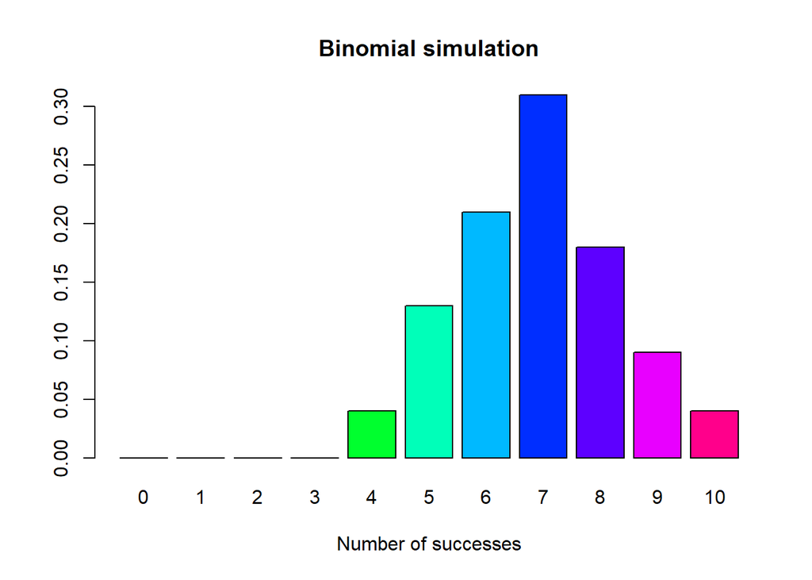

```
##
##    0    1    2    3    4    5    6    7    8    9   10
## 0.00 0.00 0.00 0.00 0.04 0.13 0.21 0.31 0.18 0.09 0.04
```

```r
mybin(100,10,0.7)
```

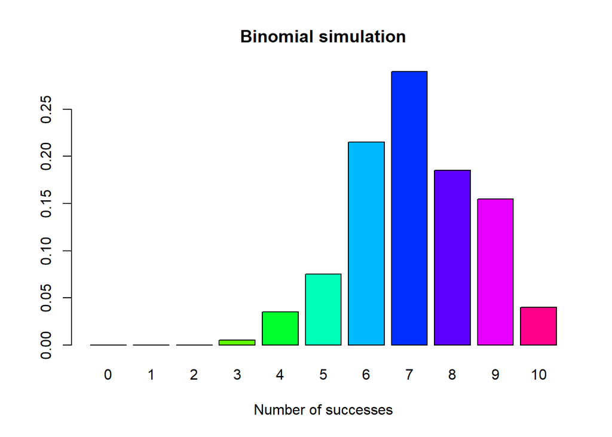

```
##
##     0     1     2     3     4     5     6     7     8     9    10
## 0.000 0.000 0.000 0.005 0.035 0.075 0.215 0.290 0.185 0.155 0.040
```

```r
mybin(200,10,0.7)
```

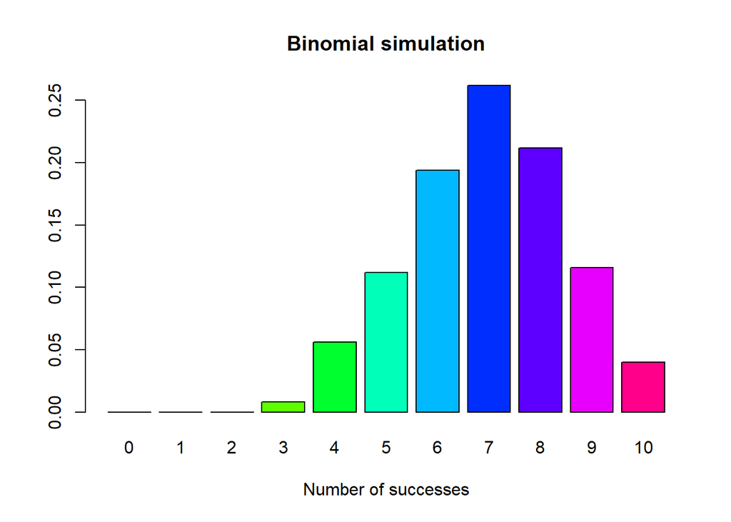

```
##
##     0     1     2     3     4     5     6     7     8     9    10
## 0.000 0.000 0.000 0.008 0.056 0.112 0.194 0.262 0.212 0.116 0.040
```

```r
mybin(500,10,0.7)
```

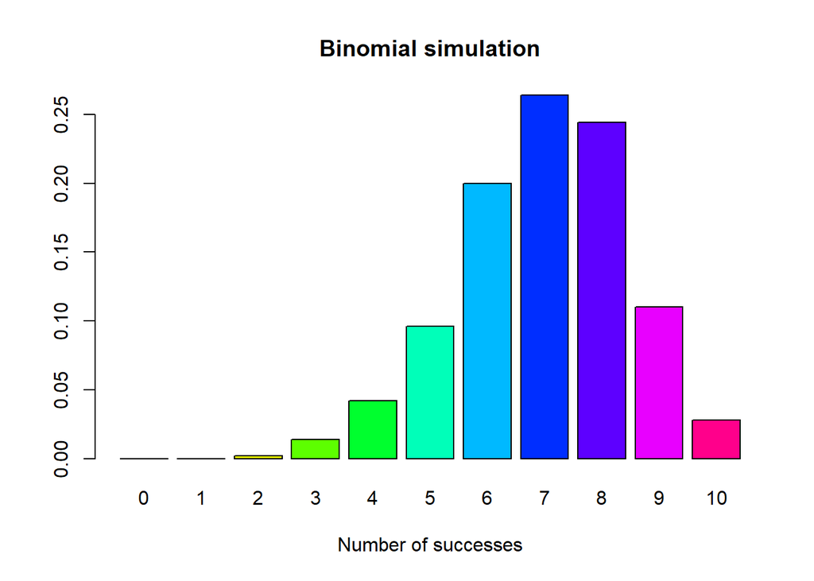

```
##
##     0     1     2     3     4     5     6     7     8     9    10
## 0.000 0.000 0.002 0.014 0.042 0.096 0.200 0.264 0.244 0.110 0.028
```

```r
mybin(1000,10,0.7)
```

### For the last simulation (10,000 iterations) copy and paste the table that is produced from the function.

```r
mybin(10000,10,0.7,TRUE)
```

```
##
##    0    1    2    3    4    5    6    7    8    9   10
##    0    0   21   95  371 1029 1984 2670 2296 1243  291
```

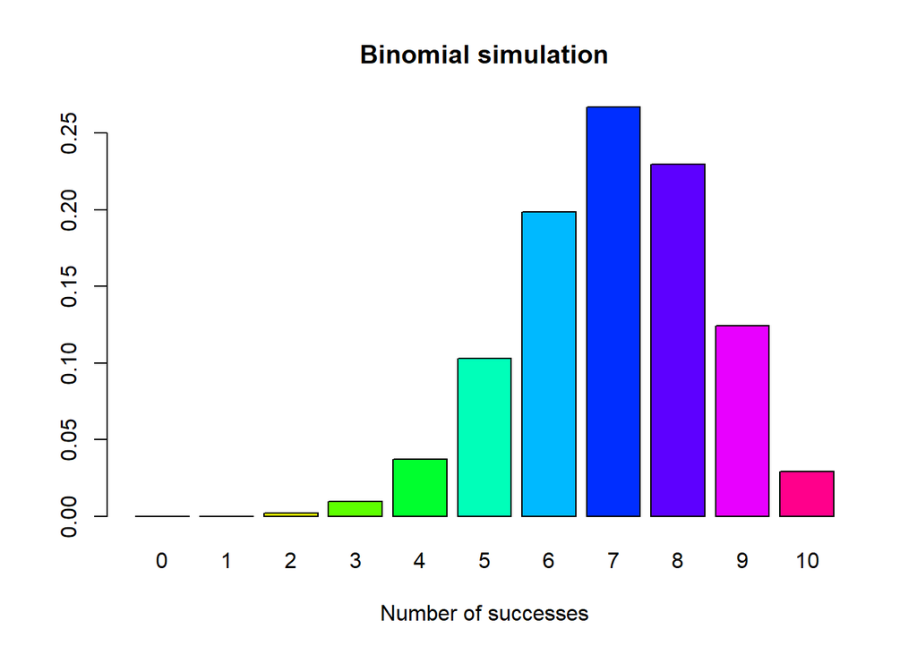

```
##
##      0      1      2      3      4      5      6      7      8      9     10
## 0.0000 0.0000 0.0021 0.0095 0.0371 0.1029 0.1984 0.2670 0.2296 0.1243 0.0291
```

### Verify that each value in the table is approximately correct using dbinom() – you will need to look up the function using ?dbinom

```r
dbinom(1:10,10,0.7)
```

```
##  [1] 0.000137781 0.001446701 0.009001692 0.036756909 0.102919345 0.200120949
##  [7] 0.266827932 0.233474440 0.121060821 0.028247525
```

> Yes, approximately correct

## Task 3

### Suppose that there is a bag of 20 marbles, 12 white (“1”) and 8 black “0”. Create a sample of size n=5 without replacement

```r
sample(c("0","0","0","0","0","0","0","0",
         "1","1","1","1","1","1","1","1","1","1","1","1")
       ,size=5)
```

```
## [1] "1" "1" "0" "1" "0"
```

### Now do the same with replace=TRUE.

```r
sample(c("0","1"),size=5,replace=TRUE)
```

```
## [1] "0" "0" "0" "1" "0"
```

### Use the function myhyper(), on CANVAS, assume Y = number of whites, remember sampling is without replacement, n=5.

```r
myhyper=function(iter=100,N=20,r=12,n=5,flag=FALSE){
# make a matrix to hold the samples
#initially filled with NA's
sam.mat=matrix(NA,nr=n,nc=iter, byrow=TRUE)
#Make a vector to hold the number of successes over the trials
succ=c()
for( i in 1:iter){
#Fill each column with a new sample
sam.mat[,i]=sample(rep(c(1,0),c(r,N-r)),n,replace=FALSE)
#Calculate a statistic from the sample (this case it is the sum)
succ[i]=sum(sam.mat[,i])
}

#Make a table of successes
succ.tab=table(factor(succ,levels=0:n))
if(flag==TRUE){
  print(succ.tab)
}
#Make a barplot of the proportions
barplot(succ.tab/(iter), col=rainbow(n+1), main="HYPERGEOMETRIC simulation", xlab="Number of successes")
succ.tab/iter
}
```

### Use this code to make barplots of Y for the following number of iterations

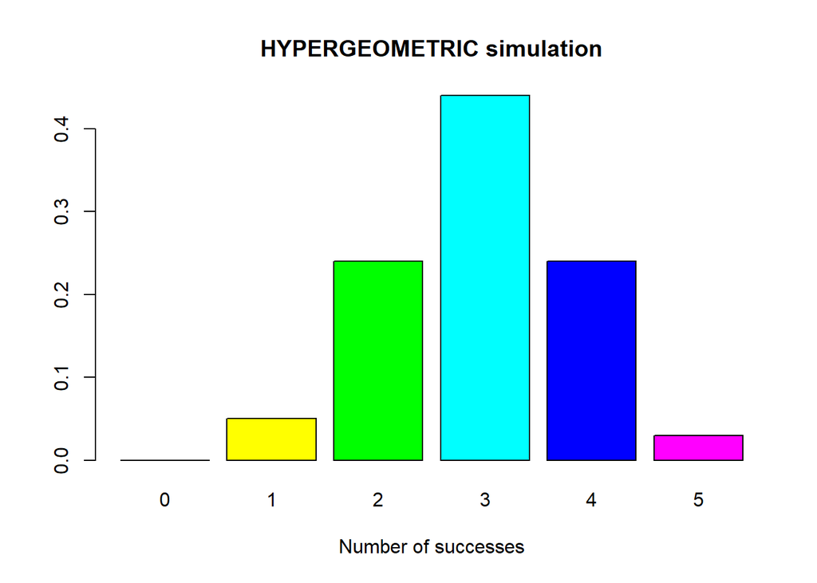

```
##
##    0    1    2    3    4    5
## 0.00 0.05 0.24 0.44 0.24 0.03
```

```r
myhyper()
```

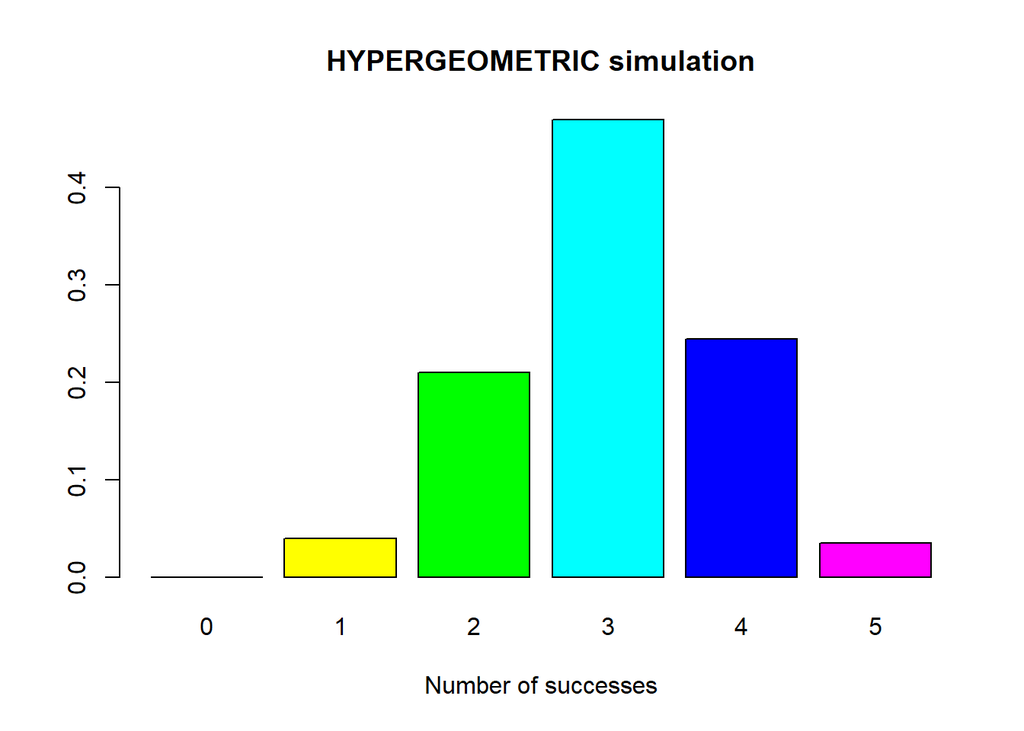

```
##
##     0     1     2     3     4     5
## 0.000 0.040 0.210 0.470 0.245 0.035
```

```r
myhyper(iter=200)
```

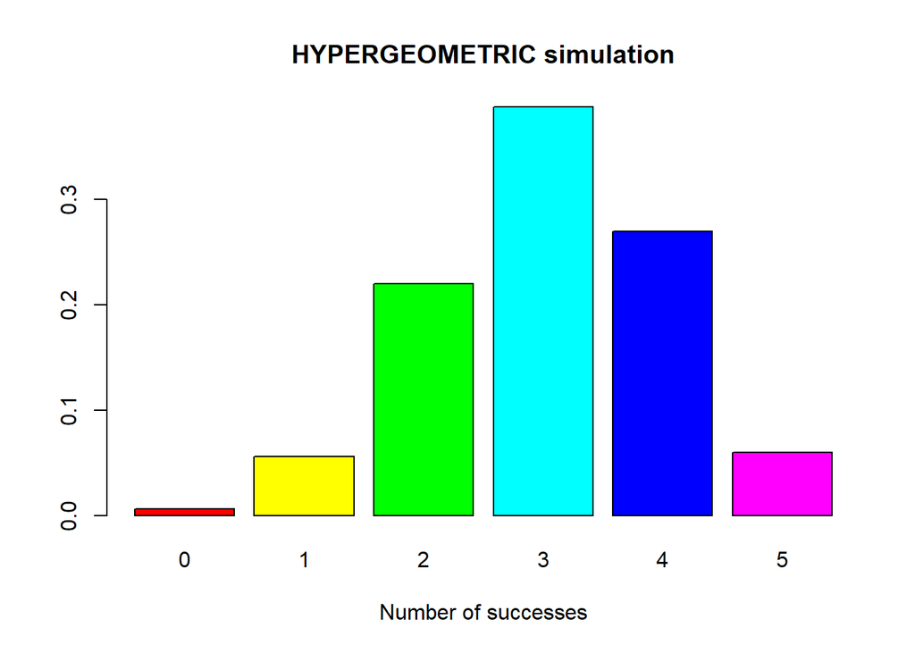

```
##
##     0     1     2     3     4     5
## 0.006 0.056 0.220 0.388 0.270 0.060
```

```r
myhyper(iter=500)
```

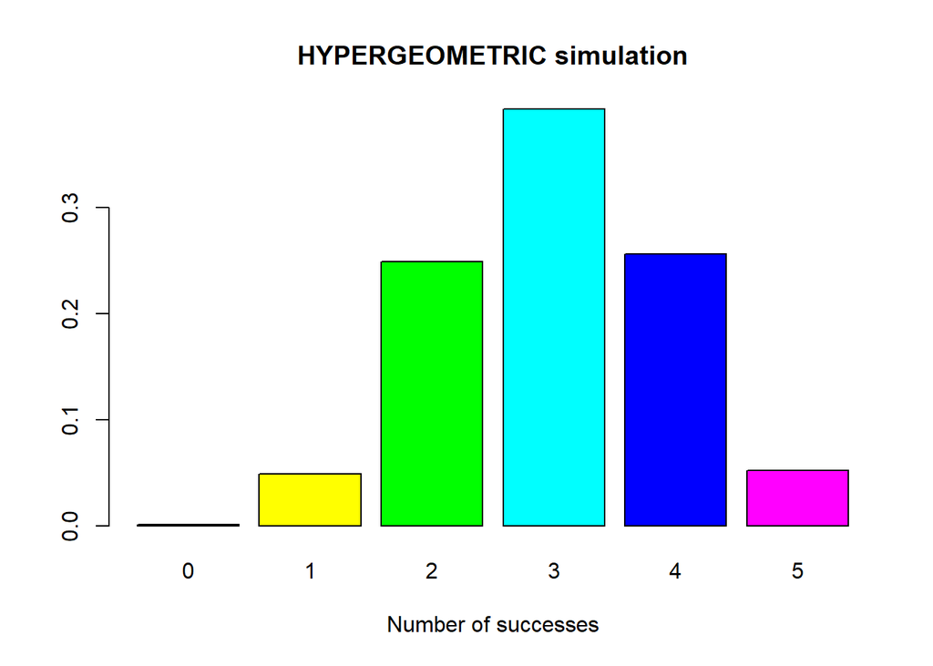

```
##
##     0     1     2     3     4     5
## 0.001 0.049 0.249 0.393 0.256 0.052
```

```r
myhyper(iter=1000)
```

### For the last simulation (10,000 iterations) copy and paste the table that is produced from the function.

```r
myhyper(iter=10000,flag=TRUE)
```

```
##
##    0    1    2    3    4    5
##   29  539 2429 3813 2619  571
```

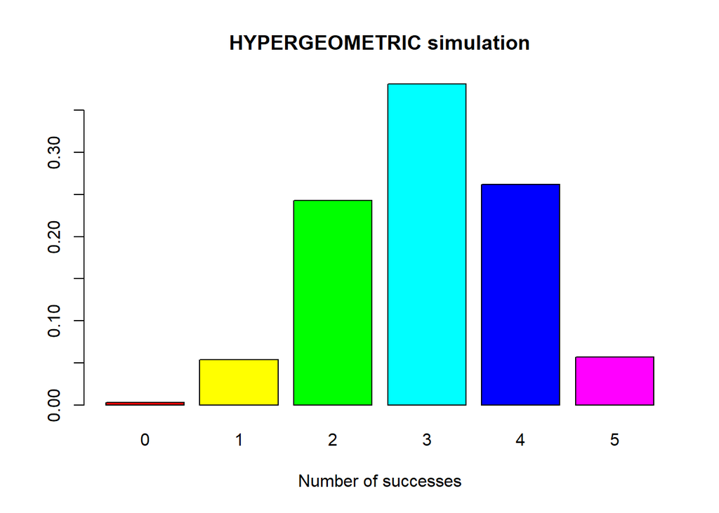

```
##
##      0      1      2      3      4      5
## 0.0029 0.0539 0.2429 0.3813 0.2619 0.0571
```

### Verify that each value in the table is approximately correct using dhyper()

```r
dhyper(x=0:5, m=12, n=8, k=5)
```

```
## [1] 0.003611971 0.054179567 0.238390093 0.397316821 0.255417957 0.051083591
```

> Values are very close

## Task 4

### In lab5.r there is a function called mysample(). Look at the code and describe what you think it should do – record your response here.

```r
mysample=function(n, iter=10,time=0.5){
  for( i in 1:iter){
    #make a sample
    s=sample(1:10,n,replace=TRUE)
    # turn the sample into a factor
    sf=factor(s,levels=1:10)
    #make a barplot
    barplot(table(sf)/n,beside=TRUE,col=rainbow(10),
    main=paste("Example sample()", " iteration ", i, " n= ", n,sep="") ,
    ylim=c(0,0.2))
    #release the table
    ##Sys.sleep(time)
  }
}
```

> This function is making samplings between number 1 to 10. number of iterration is depending on the user input. Then it make a graph out of the probability of the numbers. The graph y axis is limited between 0 and 0.2

### Run the function with the following arguments mysample(n=1000, iter=30,time=1)

```r
  mysample(n=1000, iter=30,time=1)
```

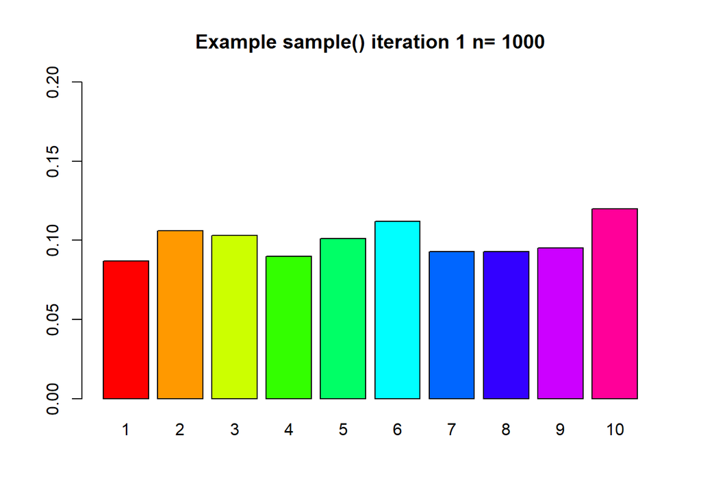

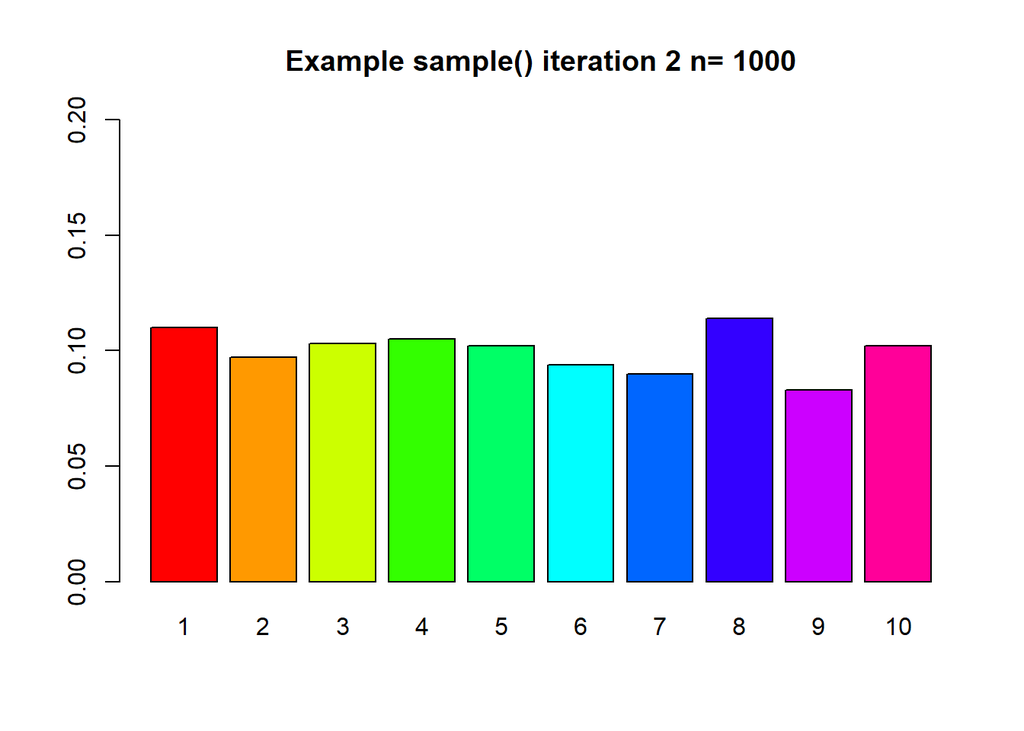

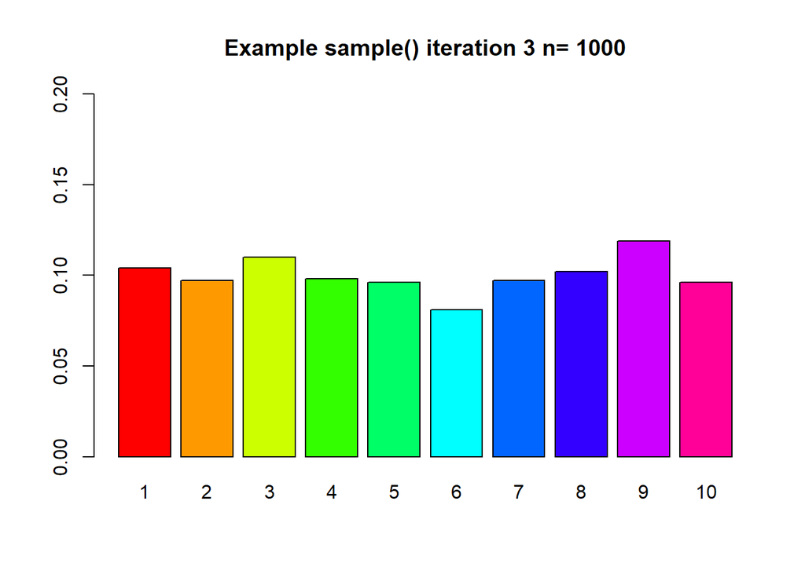

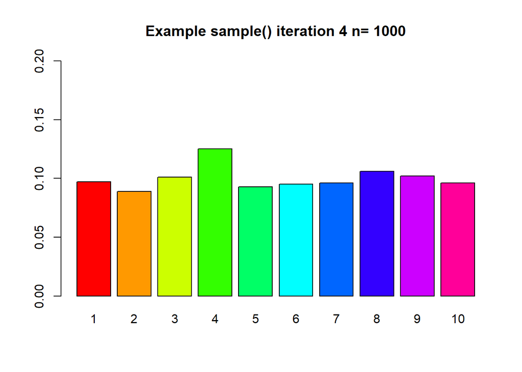

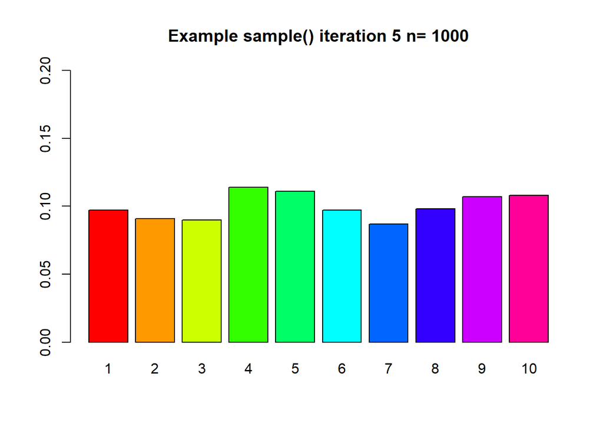

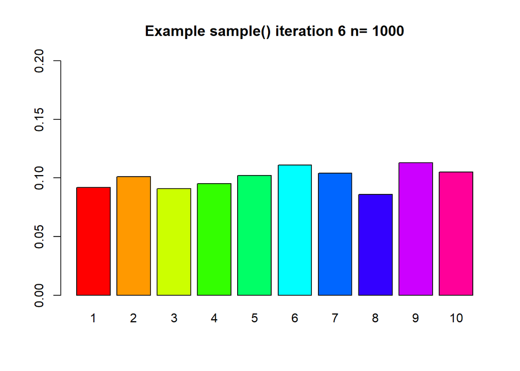

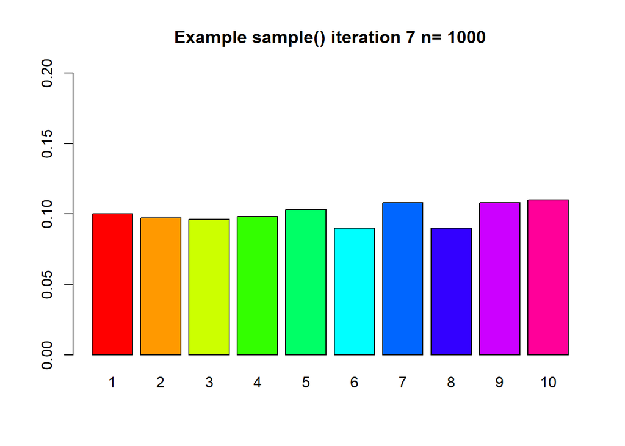

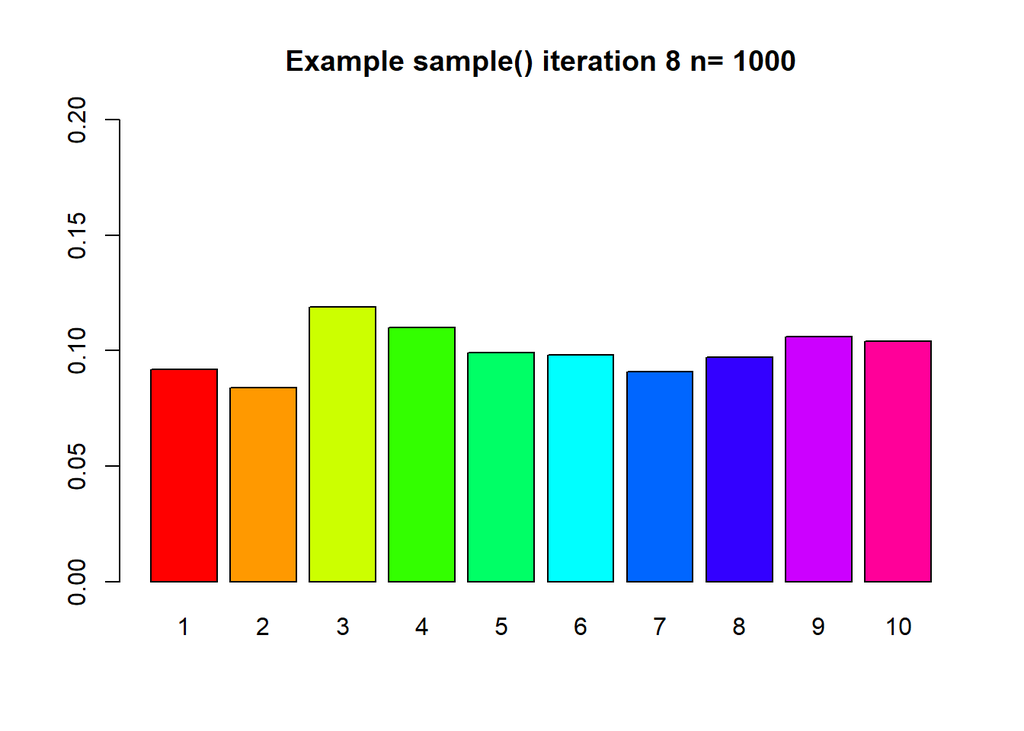

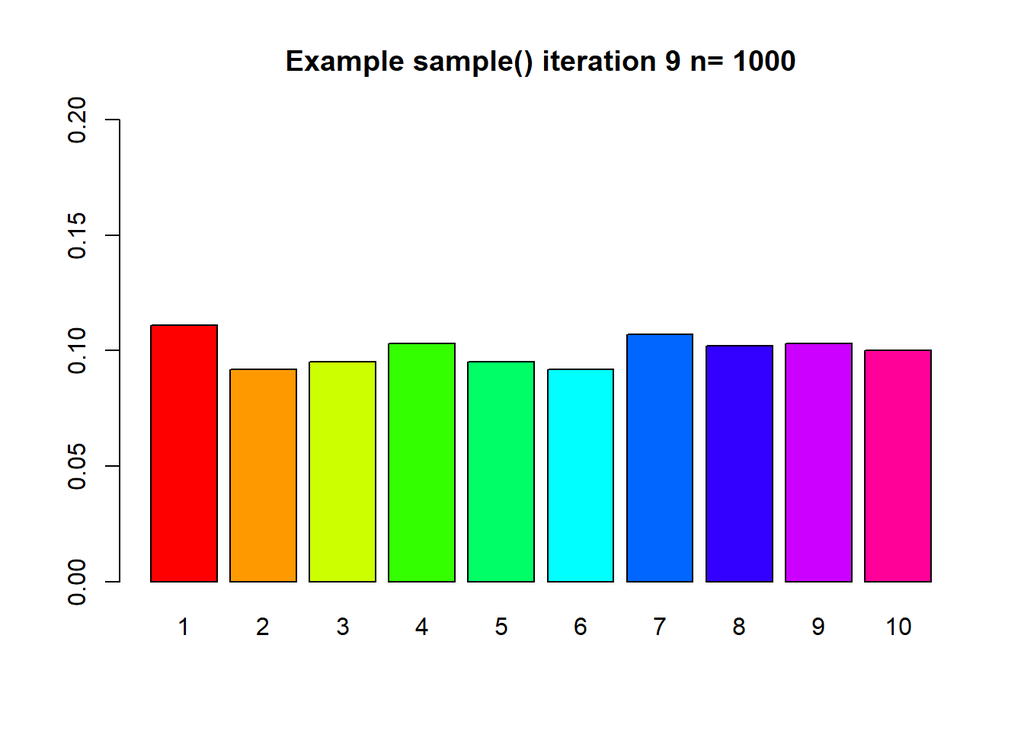

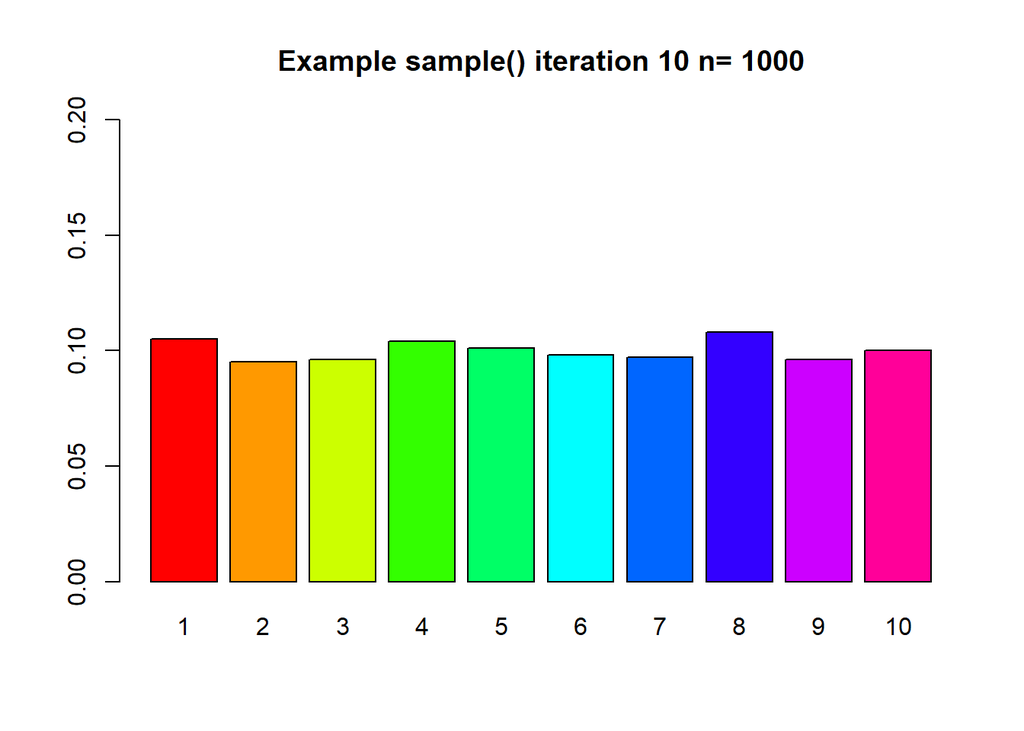

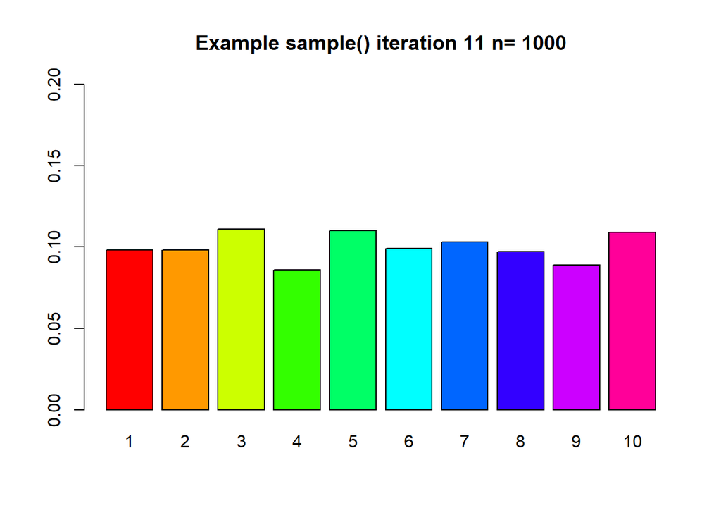

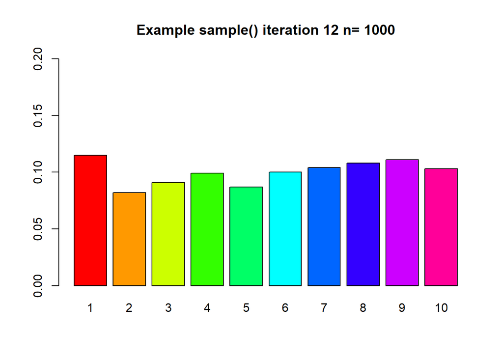

[18 more figures not shown]

### Describe what you see here.

> I see 30 iterations of samplings between number 1 to 10, portray with thier probability of appearance

## Task 5

### Use R to calculate

#### 8 choose 4

```r
choose(8,4)
```

```
## [1] 70
```

#### P(Y>4),Y~Pois(λ=2)

```r
ppois(4,2,lower.tail = FALSE)
```

```
## [1] 0.05265302
```

### Some more calculations in R

#### P(Y=10),Y~NegBin(p=0.4,r=3) see CANVAS which has a full explanation of this.

```r
#  This means that in R we need n=3 (size), x=y-r=10-3=7
dnbinom(7,3,0.4)  # Nu Failures, Nu of successes, prob success
```

```
## [1] 0.06449725
```

```r
mynbin=function(y,r,p){
  choose(y-1,r-1)*p^r*(1-p)^(y-r)
}
mynbin(10,3,0.4)
```

```
## [1] 0.06449725
```

#### P(Y≤8),Y~Bin(n=15,p=0.4)

```r
  pbinom(8,15,0.4)
```

```
## [1] 0.9049526
```

## Task 6

### Create an R function by copying code from this lab.

### Document the function using roxygen

### Place the function into your package

### Install and restart the package using the icon in R studio

### Invoke the function by doing the following – suppose your function is called myf()

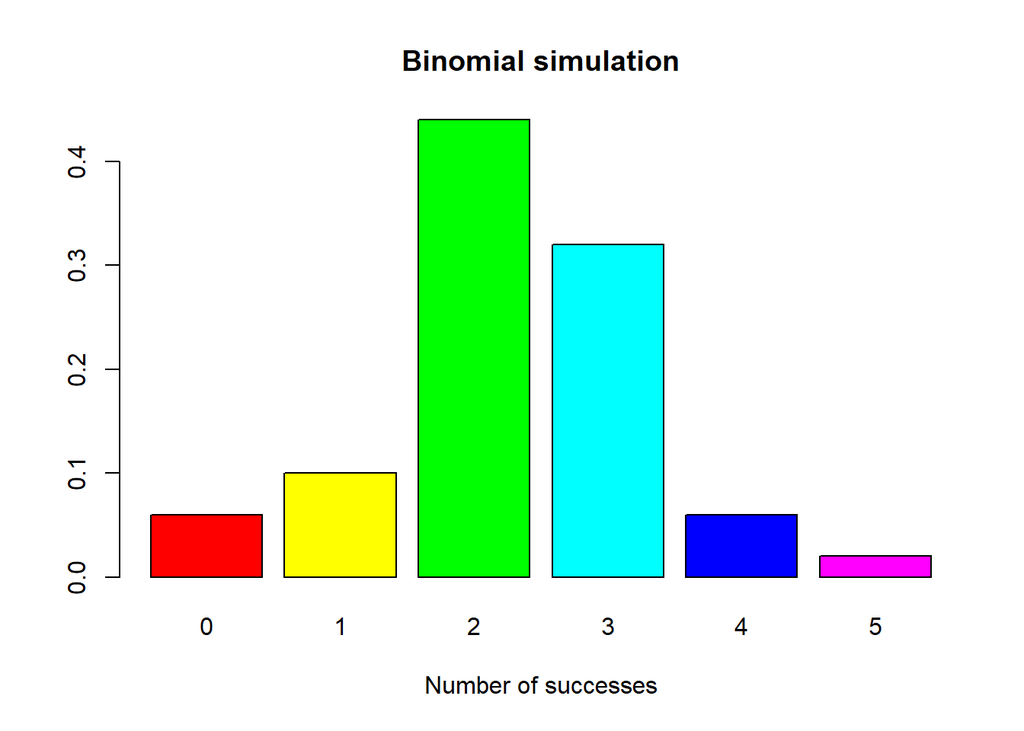

```
##
##    0    1    2    3    4    5
## 0.06 0.10 0.44 0.32 0.06 0.02
```

```r
mypackage::mybin(50,5,0.5)
```